# Taller De Regresion Lineal Multiple

Econometria I 2019-02

Andres Felipe Sabogal Ramirez

30/5/2020

# Algunas Formulas Importantes Para Comenzar

$$TSS=\sum_{i=1}^{n}(y_1-\overline{y})^2$$

$$ESS=\sum_{i=1}^{n}(\hat{y_i}-\overline{y})^2$$
$$RSS=\sum_{i=1}^{n}(y_i-\hat{y_i})^2=e^2$$

# Primer Punto

1. Se supone que la inversión es una protección contra la inflación si su precio y/o tasa de retorno, al menos, se mantiene al ritmo de la inflación. Para probar esta hipótesis, se decide ajustar los modelos

Modelo 1
$$P_{oro}=\beta_1+\beta_2IPC_t+\mu_t$$
Modelo 2
$$BVNY_{t}=\beta_1+\beta_2IPC_t+\mu_t$$

## Lectura de Datos

```r
rm(list=ls()) # rm remueve objetos, ls = lista
setwd('C://Users/f-pis/Desktop/Semestres/Archivos R') #Establece el workDirectory
#install.packages("readxl") # instala el paquete para leer Excel
library(readxl) #..library() Carga el paquete
library(normtest)
Datos_1P <- read_excel("Datos_E1_Precio_Oro_BVNY.xls") #read_excel lee el excel
Datos_1P=data.frame(Datos_1P) # Aqui se estable que Tiempo es una hoja de Excel
attach(Datos_1P) # attach() carga los datos
#install.packages("knitr")
library(knitr)
knitr::kable(
  head(Datos_1P), caption = "Head Datos Primer Punto",align = "c")
```

Head Datos Primer Punto

| Date | Poro | BVNY | IPC |
| --- | --- | --- | --- |
| 1974 | 59.26 | 511.354 | 49.3 |
| 1975 | 61.02 | 513.355 | 53.8 |
| 1976 | 24.84 | 522.585 | 56.9 |
| 1977 | 57.71 | 521.766 | 60.6 |
| 1978 | 93.22 | 521.781 | 65.2 |
| 1979 | 206.68 | 526.668 | 72.6 |

## Definimos los dos modelos de inversion

```r
# el modelo 1 es Poro_t= beta1 + beta2*IPC_t +U_t

Mod_1<-lm(Datos_1P$Poro~Datos_1P$IPC)
"Esta es la regresion del primer modelo"
```

```
## [1] "Esta es la regresion del primer modelo"
```

```r
(summary(Mod_1))
```

```
##
## Call:
## lm(formula = Datos_1P$Poro ~ Datos_1P$IPC)
##
## Residuals:
##      Min       1Q   Median       3Q      Max
## -150.557  -90.711    5.178   37.052  310.944
##
## Coefficients:
##              Estimate Std. Error t value Pr(>|t|)
## (Intercept)  116.8937    54.2597   2.154   0.0391 *
## Datos_1P$IPC   1.0282     0.4022   2.556   0.0157 *
## ---
## Signif. codes:  0 '***' 0.001 '**' 0.01 '*' 0.05 '.' 0.1 ' ' 1
##
## Residual standard error: 102.7 on 31 degrees of freedom
## Multiple R-squared:  0.1741, Adjusted R-squared:  0.1474
## F-statistic: 6.534 on 1 and 31 DF,  p-value: 0.0157
```

```r
plot(Mod_1)
e1<-residuals(Mod_1)
hist(e1)
boxplot(e1, main="Boxplot residuals") # grafica de caja de los errores de estimacion (et)
"Prueba de jarque-bera"
```

```
## [1] "Prueba de jarque-bera"
```

```r
jb.norm.test(e1) # Prueba de normalidad Jarque-Bera
```

```
##
##  Jarque-Bera test for normality
##
## data:  e1
## JB = 5.5814, p-value = 0.033
```

```r
"Intervalos de Confianza"
```

```
## [1] "Intervalos de Confianza"
```

```r
(Intervalos_1<-confint(Mod_1))
```

```
##                  2.5 %     97.5 %
## (Intercept)  6.2302421 227.557098
## Datos_1P$IPC 0.2078211   1.848546
```

```r
# El modelo 2 es BVNY_t=beta1 + beta2*IPC_t + U_t

Mod_2<-lm(Datos_1P$BVNY~Datos_1P$IPC)
"Esta es la regresion del segundo modelo"
```

```
## [1] "Esta es la regresion del segundo modelo"
```

```r
summary(Mod_2)
```

```
##
## Call:
## lm(formula = Datos_1P$BVNY ~ Datos_1P$IPC)
##
## Residuals:
##     Min      1Q  Median      3Q     Max
## -132.20  -82.40  -34.44   96.46  166.31
##
## Coefficients:
##              Estimate Std. Error t value Pr(>|t|)
## (Intercept)  120.5008    53.3967   2.257   0.0312 *
## Datos_1P$IPC   5.0297     0.3958  12.707  7.9e-14 ***
## ---
## Signif. codes:  0 '***' 0.001 '**' 0.01 '*' 0.05 '.' 0.1 ' ' 1
##
## Residual standard error: 101 on 31 degrees of freedom
## Multiple R-squared:  0.8389, Adjusted R-squared:  0.8337
## F-statistic: 161.5 on 1 and 31 DF,  p-value: 7.895e-14
```

```r
plot(Mod_2)
e2<-residuals(Mod_2)
hist(e2)
boxplot(e2, main="Boxplot residuals") # grafica de caja de los errores de estimacion (et)
jb.norm.test(e2) # Prueba de normalidad Jarque-Bera
```

```
##
##  Jarque-Bera test for normality
##
## data:  e2
## JB = 3.0839, p-value = 0.083
```

```r
(Intervalos_2<-confint(Mod_2))
```

```
##                  2.5 %     97.5 %
## (Intercept)  11.597433 229.404209
## Datos_1P$IPC  4.222402   5.837033
```

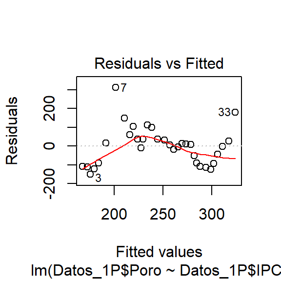

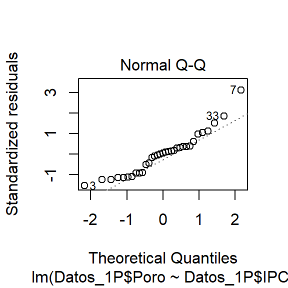

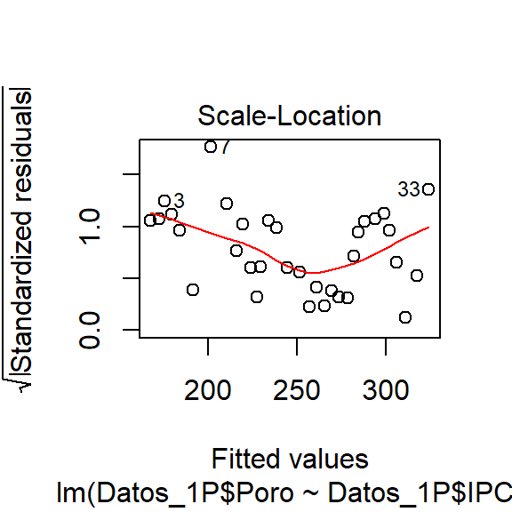

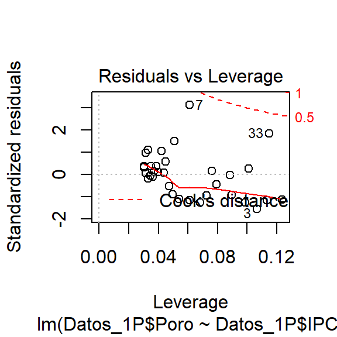

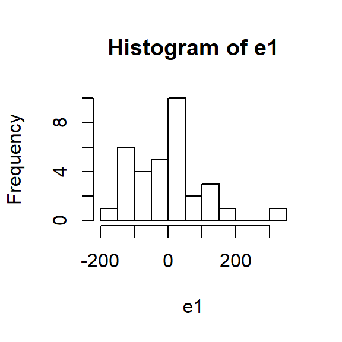

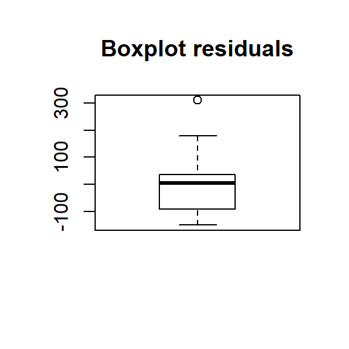

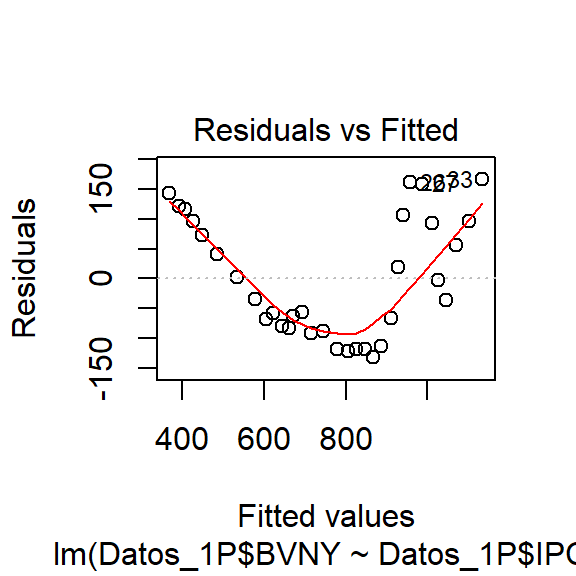

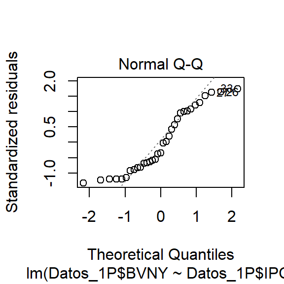

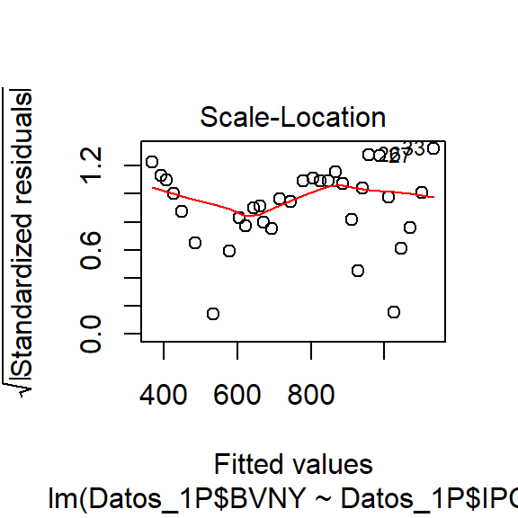

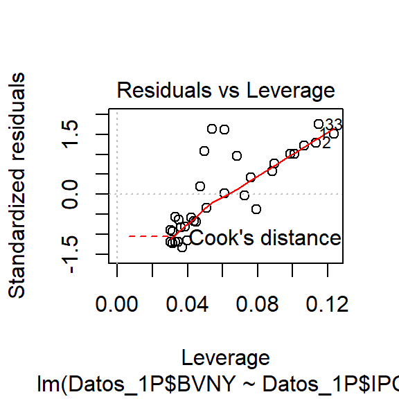

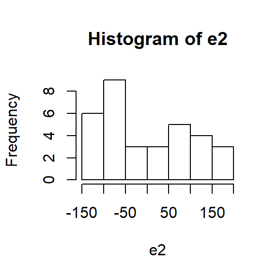

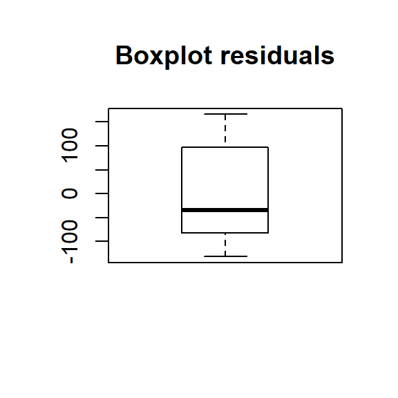

Como conclusion se obsrva que el segundo modelo es mejor ya que tiene un R2 cercano a uno y en su grafica de cuantiles se observa que se ajusta a la distribucion normal, sin embargo en la grafica Residuals Vs fitted del modelo 2 se observa que puede que el modelo no sea lineal.

# SEGUNDO PUNTO

Se formula el siguiente modelo para estudiar la relación entre X e Y: Se quiere estimar el modelo:

$$Y_{i}=\beta_1+\beta_2X_{i}+\mu_t$$

##REGRESION GASTO-INGRESOS POR HOGARES

```r
setwd('C://Users/f-pis/Desktop/Semestres/Archivos R')
Datos_2P<-read_excel("Datos_E2_Gastos_Ingreso_Hogares.xls")
Datos_2P=data.frame(Datos_2P)

library(knitr)
knitr::kable(
  head(Datos_2P), caption = "Head Datos Segundo Punto",align = "c")
```

Head Datos Segundo Punto

| Hogar | Y | X |
| --- | --- | --- |
| 1 | 9.46 | 25.83 |
| 2 | 10.56 | 34.31 |
| 3 | 14.81 | 42.50 |
| 4 | 21.71 | 46.75 |
| 5 | 22.79 | 48.29 |
| 6 | 18.19 | 48.77 |

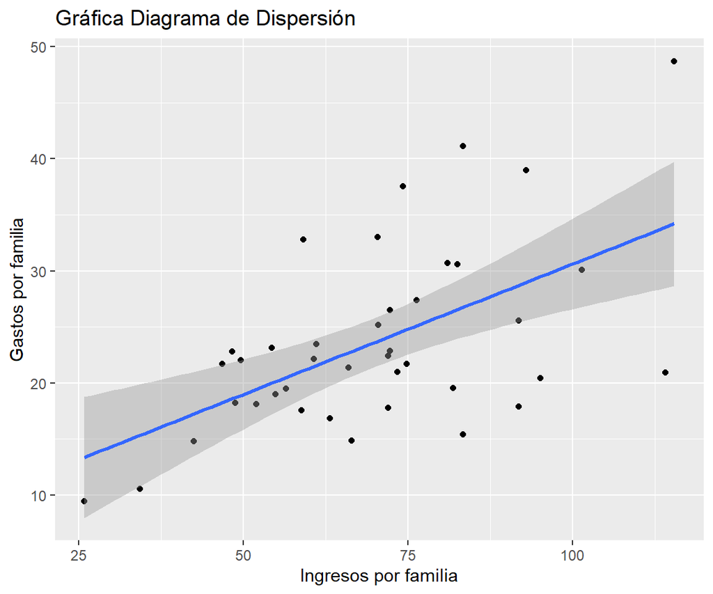

```r
# Se busca estudiar la relacion que existe entre X e Y
# Se quiere estimar el modelo Y_i= beta_1+beta_2*X_i + U_i  con i=1.....40

#install.packages("ggplot2")

if (!require('ggplot2'))
{
  install.packages('ggplot2');
  library(ggplot2);
}
library(ggplot2)
ggplot(Datos_2P, aes(x=X, y=Y)) + geom_point() + ggtitle("Gráfica Diagrama de Dispersión") + xlab("Ingresos por familia") + ylab("Gastos por familia") + geom_smooth(method=lm)
```

En la grafica de dispersion de ingresos Vs Gastos se puede observar una relacion lineal representada por la linea azul

## Estimacion Por Metodo Matricial OLS

```r
X_2P <- as.matrix(cbind(1,Datos_2P[,3]))
Y_2P <- as.matrix(Datos_2P[,2])
#Reg2=lm(Y_2P~Datos_3[,3:5])

XtX_2 = t(X_2P)%*%X_2P  # Este es el resultado de multiplicar X traspuesta por X
XtX_2  # X Traspuesta por X (Xt*X)
```

```
##      [,1]     [,2]
## [1,]   40   2792.0
## [2,] 2792 210206.2
```

```r
XtX_inv_2 <- solve(XtX_2)  # LA FUNCION solve() halla la INVERSA de la matriz
XtX_inv_2
```

```
##              [,1]          [,2]
## [1,]  0.342922190 -4.554759e-03
## [2,] -0.004554759  6.525443e-05
```

```r
Xty_2 <- t(X_2P)%*%Y_2P # Resultado de X traspuesta por y ...
Xty_2
```

```
##          [,1]
## [1,]   943.48
## [2,] 69417.39
```

```r
b_2 <- XtX_inv_2%*%Xty_2 #  Resultado de los estimadores b = (Xt*X)inv*Xt*y
"Estos son los coeficientes estimados OLS"
```

```
## [1] "Estos son los coeficientes estimados OLS"
```

```r
b_2
```

```
##           [,1]
## [1,] 7.3607278
## [2,] 0.2324681
```

```r
Ye_2 <- X_2P%*%b_2 #Calcula yt estimado
"Estos son los Y estimados por el modelo "
```

```
## [1] "Estos son los Y estimados por el modelo "
```

```r
#OJO estos son los resultados estimados de y de acuerdo a los valores encontrados de los coeficientes
plot(Y_2P,Ye_2, main = "Grafica Y Vs Y_estimado", )  # Se grafica Y de los datos iniciales (y)  contra Y estimado (yte)
e_2 <- Y_2P - Ye_2  # et es el vector de errores de estimacion (Ydado-Yestimado)
(summary(e_2))  # Aqui se muestra en consola un summary de los errores de estimacion (et)
```

```
##        V1
##  Min.   :-12.992
##  1st Qu.: -3.606
##  Median : -1.071
##  Mean   :  0.000
##  3rd Qu.:  3.225
##  Max.   : 14.509
```

```r
hist(e_2, prob=TRUE,main="Histogram e")   #Histograma de los errores de estimacion
curve(dnorm(x,mean = 0,sd=1),col=1,lty=2,lwd=3,add = TRUE) # Agrega una curva normal con media en cero y desviacion estandar 1
boxplot(e_2,main="Boxplot e") # grafica de caja de los errores de estimacion (et)
"Prueba Jarque-bera sobre los errores"
```

```
## [1] "Prueba Jarque-bera sobre los errores"
```

```r
jb.norm.test(e_2) # Prueba de normalidad Jarque-Bera
```

```
##
##  Jarque-Bera test for normality
##
## data:  e_2
## JB = 1.0813, p-value = 0.495
```

```r
g1_qq <- qqnorm(e_2,col="black") # Genera una Q-Q plot que es un metodo para comparar distrubuciones de probabilidad de una muestra aleatoria y una de comparacion
qqline(e_2,col="red") # qqline agrega a la grafica anterior una linea de tendencia teorica de cuantiles de una distribucion normal

# OTRA FORMA PARA YT vs YTE
# De esta manera de grafica y y se agrega la linea LINES de yte estimado
plot(Y_2P,t="l",main="Y Vs Y estimado") #   "l" significa linea, p significa puntos
lines(Ye_2,lty=4,col=2)
legend(x=0,y=40,legend = c("observado","estimado"),col = c(1,2),lty = c(1,4) ) #"lty" significa 1=linea, 4= punto y linea

"Estimacion con lm"
```

```
## [1] "Estimacion con lm"
```

```r
Reg2lm=lm(X_2P~Y_2P)
(summary(Reg2lm))
```

```
## Response Y1 :
##
## Call:
## lm(formula = Y1 ~ Y_2P)
##
## Residuals:
##        Min         1Q     Median         3Q        Max
## -6.940e-15  5.500e-18  2.567e-16  3.933e-16  7.376e-16
##
## Coefficients:
##              Estimate Std. Error   t value Pr(>|t|)
## (Intercept) 1.000e+00  5.796e-16 1.725e+15   <2e-16 ***
## Y_2P        4.180e-17  2.325e-17 1.798e+00   0.0801 .
## ---
## Signif. codes:  0 '***' 0.001 '**' 0.01 '*' 0.05 '.' 0.1 ' ' 1
##
## Residual standard error: 1.188e-15 on 38 degrees of freedom
## Multiple R-squared:  0.4964, Adjusted R-squared:  0.4831
## F-statistic: 37.45 on 1 and 38 DF,  p-value: 3.902e-07
##
##
## Response Y2 :
##
## Call:
## lm(formula = Y2 ~ Y_2P)
##
## Residuals:
##     Min      1Q  Median      3Q     Max
## -24.692 -12.585  -1.147   7.793  47.997
##
## Coefficients:
##             Estimate Std. Error t value Pr(>|t|)
## (Intercept)  37.6125     8.0971   4.645    4e-05 ***
## Y_2P          1.3646     0.3248   4.202 0.000154 ***
## ---
## Signif. codes:  0 '***' 0.001 '**' 0.01 '*' 0.05 '.' 0.1 ' ' 1
##
## Residual standard error: 16.59 on 38 degrees of freedom
## Multiple R-squared:  0.3172, Adjusted R-squared:  0.2993
## F-statistic: 17.66 on 1 and 38 DF,  p-value: 0.0001544
```

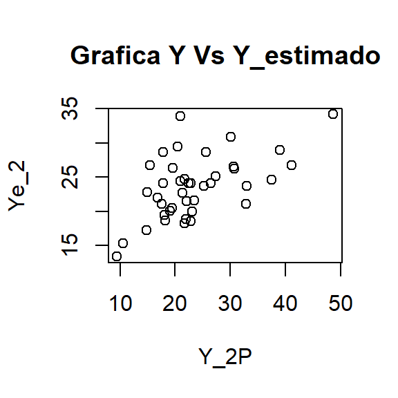

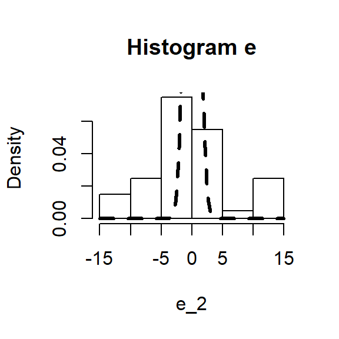

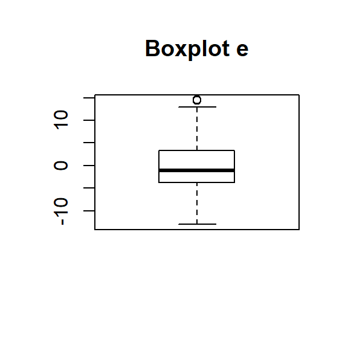

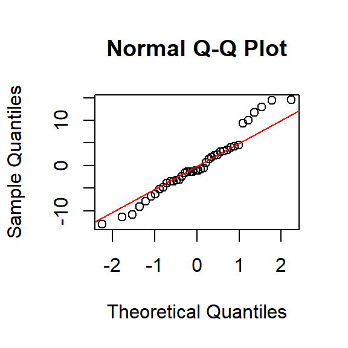

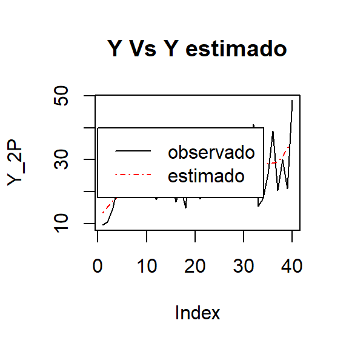

## Calculo de las sumas de cuadrados TSS, ESS y RSS

```r
TSS_2=t(Y_2P)%*%Y_2P-length(Y_2P)*mean(Y_2P)^2  # Suma de los cuadrados totales (y-ybarra)**2
#.........Tss= SUM Y**2-n*Y_barra**2
"Este es el TSS"
```

```
## [1] "Este es el TSS"
```

```r
TSS_2
```

```
##          [,1]
## [1,] 2610.594
```

```r
ESS_2=t(b_2)%*% XtX_2 %*%b_2-length(Y_2P)*mean(Y_2P)^2 # Suma de los cuadrados explicados (yest-ybarra)**2   .....ESS= b'*(X'X)*b-n*Y_barra**2
"Este es el ESS"
```

```
## [1] "Este es el ESS"
```

```r
ESS_2
```

```
##          [,1]
## [1,] 828.1646
```

```r
RSS_2=t(e_2)%*%e_2   # suma de cuadrados residuales (yi-yest)**2 ......(et_traspuesto*et)
"Este es el RSS"
```

```
## [1] "Este es el RSS"
```

```r
RSS_2
```

```
##         [,1]
## [1,] 1782.43
```

```r
TSS_e16_2=ESS_2+RSS_2  # las uma de cuadrados totales es igual al RSS + ESS
"Esta es la suma TSS=ESS+RSS"
```

```
## [1] "Esta es la suma TSS=ESS+RSS"
```

```r
TSS_e16_2
```

```
##          [,1]
## [1,] 2610.594
```

```r
RC_2<-ESS_2[1,1]/TSS_2[1,1]  # calculo del coeficiente de determinacion R_Cuadrado
"Este es el coeficiente de determinacion R^2"
```

```
## [1] "Este es el coeficiente de determinacion R^2"
```

```r
RC_2
```

```
## [1] 0.3172322
```

Luego el coeficiente de determinacion R2 es bajo y explica el 31.72% de la varianza del modelo

## Estimacion De La Varianza y Pruebas De Significancia Individual

```r
# Recordar que b~N(beta,Sigma**2(X'X)Inv) Donde b es el vector de estimadores hallados

# Recordar que Var b_estimado=s**2*(X'X)inv

S2_2<- RSS_2[1,1]/38 # Aqui se hala la varianza S**2estimado=RSS/(n-k)=et**2/(n-k) ES UN ESCALAR
Var_b2=S2_2*XtX_inv_2 # Matriz de varianzas y covarianzas ___Los elementos de la diagonal de la matriz contienen las varianzas de las variables, mientras que los elementos que se encuentran fuera de la diagonal contienen las covarianzas entre todos los pares posibles de variables.
S2b1_2=Var_b2[1,1]
S2b2_2=Var_b2[2,2]

sb1_2=sqrt(S2b1_2)
sb2_2=sqrt(S2b2_2)

colum1<-c("Coef","b1","b2")
colum2<-c("Estimación",b_2[1,1], b_2[2,1])
colum3<-c("Varianza",S2b1_2, S2b2_2)
colum4<-c("Error_Estandar",sb1_2, sb2_2)
Tabla_Coef_Var_2 <- cbind(colum1,colum2,colum3,colum4)
kable(Tabla_Coef_Var_2,caption = "Coeficientes y Varianzas ",align = "c")
```

Coeficientes y Varianzas

| colum1 | colum2 | colum3 | colum4 |
| --- | --- | --- | --- |
| Coef | Estimación | Varianza | Error_Estandar |
| b1 | 7.36072783063958 | 16.0851229232876 | 4.0106262507603 |
| b2 | 0.232468082655594 | 0.00306082705693042 | 0.0553247418153074 |

```r
""
```

```
## [1] ""
```

```r
"Pruebas de Significancia Individual"
```

```
## [1] "Pruebas de Significancia Individual"
```

```r
"|Ho: b_j=0"
```

```
## [1] "|Ho: b_j=0"
```

```r
"|Ha: b_j=/= 0"
```

```
## [1] "|Ha: b_j=/= 0"
```

```r
# Recordar que t_sub_b1=b1/Se(b1)=t_sub_c  Donde Se(b1) es la desviacion estandar de b1 sqrt(var(b1))

# Recordar que P_Val= 2*Prob[t_sub_n-k > abs(t_sub_b1)]

# Aqui se hacen las pruebas de significancia individual de cada estimador
tb1_2=b_2[1,1]/sb1_2   # VALORES t
pb1_2=2*(1-pt(abs(tb1_2),38))  # IMPORTANTE con esta funcion pt() obtenemos la probabilidad de una distribucion t-Student con 47 grados de libertad  VALORES p
tb2_2=b_2[2,1]/sb2_2
pb2_2=2*(1-pt(abs(tb2_2),38))

colum1<-c("Coef","b1","b2")
colum2<-c("Estimación",b_2[1,1], b_2[2,1])
colum4<-c("Error_Estandar",sb1_2, sb2_2)
colum5<-c("Valores t",tb1_2, tb2_2)
colum6<-c("Valores p",pb1_2, pb2_2)
Tabla_analisis_reg_2 <- cbind(colum1,colum2, colum4,colum5,colum6)
kable(Tabla_analisis_reg_2,caption = "Coeficientes y Varianzas ",align = "c")
```

Coeficientes y Varianzas

| colum1 | colum2 | colum4 | colum5 | colum6 |
| --- | --- | --- | --- | --- |
| Coef | Estimación | Error_Estandar | Valores t | Valores p |
| b1 | 7.36072783063958 | 4.0106262507603 | 1.83530635128222 | 0.0742962908246338 |
| b2 | 0.232468082655594 | 0.0553247418153074 | 4.20188282905415 | 0.000154435397409225 |

## Modelo De Regresion Lineal En Desviaciones De La Media

```r
I40 <- diag(40)  # diag() nos arroja una matriz diagonal cuadrada con unos en la diagonal
i_2 <- rep(1,40)  # Genera un vector de unos de tamaño 52
iit_2 <- i_2%*% t(i_2)  # Multiplica y da coo resultado una matriz i de unos 1 de orden 52len
#vi1 <- matrix(nrow=52, ncol=1, rep(1, 52)) #  Vector de unos
#Miit1 <- matrix(nrow=52, ncol=52, rep(1,52*52))  # Matriz de unos
A <- I40-(1/40)*iit_2  # Matriz 52X52 donde a la diagonal principal se le resta 1/52 y el resto de entredas seran 0-1/52
#X21 <- X0[1:52,2:5]   # Define una matriz de 52x4
Xa_2 <- A%*%X_2P[,2]  #  Resulta una matriz de 40x1 A*X2=A*X21
ya_2 <- A%*%Y_2P[,1]   # ya es un vector de 52 X 1 resultado de A*y
XatXa_2 <- t(Xa_2)%*%Xa_2
XatXa_2
```

```
##          [,1]
## [1,] 15324.63
```

```r
XatXa_2_inv <- solve(XatXa_2)
XatXa_2_inv
```

```
##              [,1]
## [1,] 6.525443e-05
```

```r
Xatya_2 <- t(Xa_2)%*%ya_2
Xatya_2
```

```
##          [,1]
## [1,] 3562.487
```

```r
b2_desv <- XatXa_2_inv%*%Xatya_2
"b2_desv es el vector de parametros estimados en en modelo en desviaciones"
```

```
## [1] "b2_desv es el vector de parametros estimados en en modelo en desviaciones"
```

```r
kable(b2_desv, caption = "Parametros Estimados Mod-Desv",align = "c")      # b2 es el vector de parametros estimados
```

Parametros Estimados Mod-Desv

| 0.2324681 |
| --- |

```r
# OBTENEMOS EL INTERCEPTO
# Ybarra-b2*X2barra-b3*X3barra-b4*X4barra-b5*X5barra
Intercepto_2=mean(Y_2P)-b2_desv[1,1]*mean(X_2P[,2])
"Intercepto estimado"  # Entre comillas --muestra el mensaje en la consola
```

```
## [1] "Intercepto estimado"
```

```r
Intercepto_2
```

```
## [1] 7.360728
```

```r
yde_2 <- Xa_2%*%b2_desv   # Vector de Y estimado
ed_2 <-  ya_2-yde_2      # Vector de errores de estimacion
TSSa_2=t(ya_2)%*%ya_2      # Suma de cuadrados totales
"Suma total de cuadrados del modelo en desviaciones"
```

```
## [1] "Suma total de cuadrados del modelo en desviaciones"
```

```r
TSSa_2
```

```
##          [,1]
## [1,] 2610.594
```

```r
ESSa_2=t(b2_desv)%*% XatXa_2 %*%b2_desv    # SUma de cuadrados Estimados  b2t*XatXa*b2
"Suma de cuadrados explicados del modelo en desviaciones"
```

```
## [1] "Suma de cuadrados explicados del modelo en desviaciones"
```

```r
ESSa_2
```

```
##          [,1]
## [1,] 828.1646
```

```r
RSSa_2=t(ed_2)%*%ed_2 # Suma de cuadrados residuales eta**2
"Suma de cuadrados residuales en mod de desviaciones"
```

```
## [1] "Suma de cuadrados residuales en mod de desviaciones"
```

```r
RSSa_2
```

```
##         [,1]
## [1,] 1782.43
```

```r
c=c("Modelo en desviacioes")
c1=c("TSS","ESS","RSS")
c2=c(TSSa_2,ESSa_2,RSSa_2)
Sum_cuad_desv_2=cbind(c,c1,c2)
kable(Sum_cuad_desv_2,caption = "Sumas de Cuadrados Mod-Desv",align = "c")
```

Sumas de Cuadrados Mod-Desv

| c | c1 | c2 |
| --- | --- | --- |
| Modelo en desviacioes | TSS | 2610.59424 |
| Modelo en desviacioes | ESS | 828.164615362709 |
| Modelo en desviacioes | RSS | 1782.42962463729 |

```r
"TSS=ESS+RSS"
```

```
## [1] "TSS=ESS+RSS"
```

```r
(TAAa_2s=ESSa_2+RSSa_2)
```

```
##          [,1]
## [1,] 2610.594
```

```r
"Prueba de normalidad Jarque-Bera"
```

```
## [1] "Prueba de normalidad Jarque-Bera"
```

```r
jb.norm.test(ed_2)
```

```
##
##  Jarque-Bera test for normality
##
## data:  ed_2
## JB = 1.0813, p-value = 0.4535
```

# Tercer Punto

Se tienen datos son anuales en el periodo 1947 – 2000 sobre las siguientes variables para la economía de US: C1 = Gastos de consumo real, Yd =Ingreso Real, Ri = Riqueza, y TI = Tasa de interés

Modelo P3

$$C1_{t}=\beta_1+\beta_2Yd_{t}+\beta_3RI_{t}+\beta_4TI_{t}+\mu_t$$
## Estimacion del modelo Beta2=Variacion enlos gastos con respecto a variacion en el ingreso real Beta3=Variacion en los gastos con respecto a una variacion en la riqueza disponible Beta4=Varacion en el gasto con respecto a una variacion en la tasa de interes Beta1=Intercepto en y= gasto autonomo

```r
"Estimar el modelo C1_t=B1+B2*Yd_t+B3*RI_t+B4*TI_t+U_t"
```

```
## [1] "Estimar el modelo C1_t=B1+B2*Yd_t+B3*RI_t+B4*TI_t+U_t"
```

```r
rm(list=ls()) # rm remueve objetos, ls = lista
setwd('C://Users/f-pis/Desktop/Semestres/Archivos R') #Establece el workDirectory
#install.packages("readxl") # instala el paquete para leer Excel
library(readxl) #..library() Carga el paquete
Datos_3P<-read_excel("Datos_E3_Consumo.xls") #read_excel lee el excel
Datos_3P=data.frame(Datos_3P)# Aqui se estable que Tiempo es una hoja de Excel
Datos_3P$c1<-as.numeric(Datos_3P$c1)
Datos_3P$yd<-as.numeric(Datos_3P$yd)
Datos_3P$Ri<-as.numeric(Datos_3P$Ri)
Datos_3P$ti<-as.numeric(Datos_3P$ti)
attach(Datos_3P) # attach() carga los datos
kable(head(Datos_3P),caption = "Head Datos 3P ",align = "c")
```

Head Datos 3P

| Date | c1 | yd | Ri | ti |
| --- | --- | --- | --- | --- |
| 1947 | 975.5 | 1035.2 | 5166.8 | -10351.000 |
| 1948 | 998.1 | 1090.0 | 5280.8 | -4720.000 |
| 1949 | 1025.3 | 1095.6 | 5607.4 | 1044.000 |
| 1950 | 1090.9 | 1192.7 | 5759.5 | 0.407 |
| 1951 | 1107.1 | 1227.0 | 6086.1 | -5283.000 |
| 1952 | 1142.4 | 1266.8 | 6243.9 | -0.277 |

```r
library(normtest) # carga el paquete de prueba de normalidad

X_3P <- as.matrix(cbind(1,Datos_3P[,3:5]))
Y_3P <- as.matrix(Datos_3P[,2])
XtX_3=t(X_3P)%*%X_3P  # Este es el resultado de multiplicar X traspuesta por X
XtX_3  # X Traspuesta por X..... (X'*X)
```

```
##            1           yd          Ri           ti
## 1      54.00     173654.4      833684 6.703646e+04
## yd 173654.40  699882672.2  3423310436 3.479660e+08
## Ri 833684.00 3423310436.2 16999040180 1.711348e+09
## ti  67036.46  347965965.4  1711348276 4.758595e+08
```

```r
XtX_inv_3 <- solve(XtX_3)  # LA FUNCION solve() halla la INVERSA de la matriz
XtX_inv_3
```

```
##                1            yd            Ri            ti
## 1   1.138203e-01 -6.480331e-05  6.758945e-06  7.044779e-06
## yd -6.480331e-05  1.325795e-07 -2.301159e-08 -5.060596e-09
## Ri  6.758945e-06 -2.301159e-08  4.331587e-09  2.969349e-10
## ti  7.044779e-06 -5.060596e-09  2.969349e-10  3.741649e-09
```

```r
Xty_3 <- t(X_3P)%*%Y_3P # Resultado de X traspuesta por y ...
Xty_3
```

```
##            [,1]
## 1      155998.3
## yd  631417771.8
## Ri 3097719840.4
## ti  312918407.2
```

```r
b_3 <- XtX_inv_3%*%Xty_3 #  Resultado de los estimadores b = (Xt*X)inv*Xt*y
"Estos son los coeficientes estimados OLS"
```

```
## [1] "Estos son los coeficientes estimados OLS"
```

```r
b_3
```

```
##             [,1]
## 1  -20.422436191
## yd   0.736848710
## Ri   0.035418543
## ti  -0.005724966
```

```r
"Estos son los Y estimados por el modelo "
```

```
## [1] "Estos son los Y estimados por el modelo "
```

```r
Ye_3 <- X_3P%*%b_3 #Calcula yt estimado
#OJO estos son los resultados estimados de y de acuerdo a los valores encontrados de los coeficientes


plot(Y_3P,Ye_3, main = "P3 Y Vs Y_estimado")  # Se grafica Y de los datos iniciales (y)  contra Y estimado (yte)
e_3 <- Y_3P - Ye_3  # et es el vector de errores de estimacion (Ydado-Yestimado)
summary(e_3)  # Aqui se muestra en consola un summary de los errores de estimacion (et)
```

```
##        V1
##  Min.   :-94.38719
##  1st Qu.:-22.63371
##  Median :  0.00934
##  Mean   :  0.00000
##  3rd Qu.: 19.66640
##  Max.   :128.44952
```

```r
hist(e_3, prob=TRUE )   #Histograma de los errores de estimacion
curve(dnorm(x,mean = 0,sd=9),col=1,lty=2,lwd=3,add = TRUE) # Agrega una curva normal con media en cero y desviacion estandar 3,878
boxplot(e_3, main="Boxplot e3") # grafica de caja de los errores de estimacion (et)
jb.norm.test(e_3) # Prueba de normalidad Jarque-Bera
```

```
##
##  Jarque-Bera test for normality
##
## data:  e_3
## JB = 11.193, p-value = 0.015
```

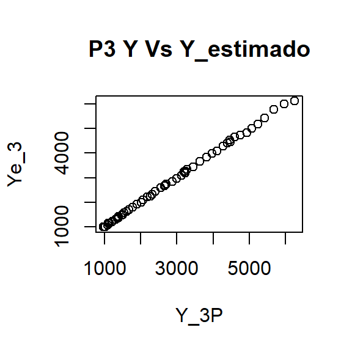

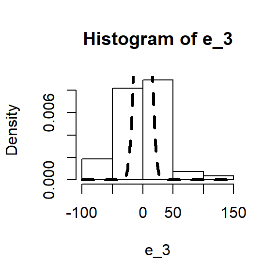

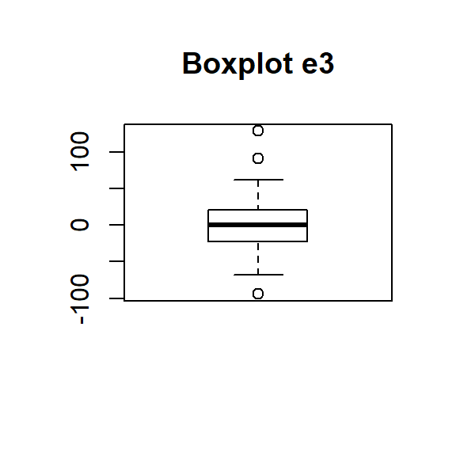

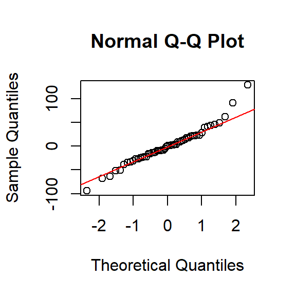

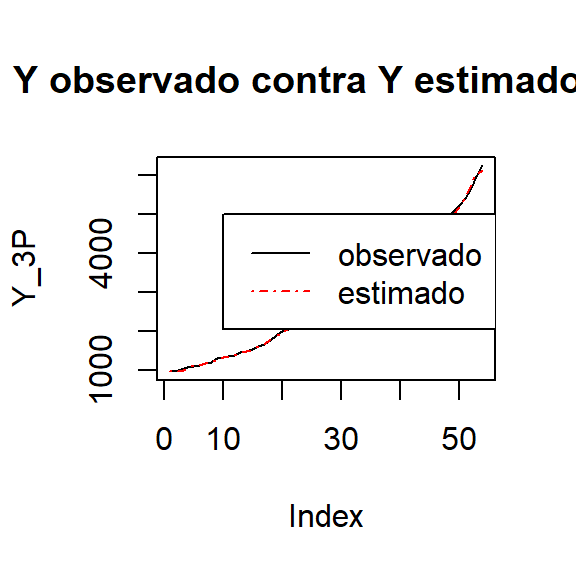

```r
g1_qq <- qqnorm(e_3,col="black") # Genera una Q-Q plot que es un metodo para comparar distrubuciones de probabilidad de una muestra aleatoria y una de comparacion
qqline(e_3,col="red") # qqline agrega a la grafica anterior una linea de tendencia teorica de cuantiles de una distribucion normal

# OTRA FORMA PARA YT vs YTE
# De esta manera de grafica y y se agrega la linea LINES de yte estimado

plot(Y_3P,t="l", main = "Y observado contra Y estimado 3P") #   "l" significa linea, p significa puntos
lines(Ye_3,lty=4,col=2)
legend(x=10,y=5000,legend = c("observado","estimado"),lty = c(1,4),col = c(1,2)) #"lty" significa 1=linea, 4= punto y linea
```

Observamos en este modelo que la prueba de jarque bera tiene un p_val<alpha, sin embargo sacamos conclusiones a partir de los graficos en donde se observa que Y vs Ye tiene fuerte relacion lineal, su boxplot tiene media en cero y ademas los errores de estimacion en la qqplot se asemejan mucho a la distribucion normal

## Estimacion de la varianza y Intervalos de confianza

```r
#x=seq(-3,3,length=100)
#y=seq(-3,3,length=100)
#parabola=function(x,y) x^3+y^2
#z=outer(x, y, parabola)
#persp(x,y,z,theta = 45)
#image(x,y,z)
#contour(x,y,z,add=T)


# Recordar que b~N(beta,Sigma**2(X'X)Inv) Donde b es el vector de estimadores hallados

# Recordar que Var b_estimado=s**2*(X'X)inv
RSS_3=t(e_3)%*%e_3
S2_3<- RSS_3[1,1]/51 # Aqui se hala la varianza S**2estimado=RSS/(n-k)=et**2/(n-k) ES UN ESCALAR
Var_b_3=S2_3*XtX_inv_3 # Matriz de varianzas y covarianzas ___Los elementos de la diagonal de la matriz contienen las varianzas de las variables, mientras que los elementos que se encuentran fuera de la diagonal contienen las covarianzas entre todos los pares posibles de variables.
S2b1_3=Var_b_3[1,1]
S2b2_3=Var_b_3[2,2]
S2b3_3=Var_b_3[3,3]
S2b4_3=Var_b_3[4,4]

sb1=sqrt(S2b1_3)
sb2=sqrt(S2b2_3)
sb3=sqrt(S2b3_3)
sb4=sqrt(S2b4_3)


# Recordar que para los intervalos de confianza se tiene que
# Intervalo= b1 +- t_(alfa/2)*S_b1  con n-2 grados de libertad
ta2=qt(0.025,51,lower.tail = FALSE)   # aqui se obtiene la funcion de quantiles de la t-Student con a/2=0.025  >>>
ta2
```

```
## [1] 2.007584
```

```r
lib1=b_3[1,1]-ta2*sb1   # Aqui se calcula el extremo superior e inferior del intervalo
lib1
```

```
##         1
## -46.47431
```

```r
lsb1=b_3[1,1]+ta2*sb1
lsb1
```

```
##        1
## 5.629434
```

```r
lib2=b_3[2,1]-ta2*sb2
lib2
```

```
##        yd
## 0.7087318
```

```r
lsb2=b_3[2,1]+ta2*sb2
lsb2
```

```
##        yd
## 0.7649656
```

```r
lib3=b_3[3,1]-ta2*sb3
lib3
```

```
##         Ri
## 0.03033633
```

```r
lsb3=b_3[3,1]+ta2*sb3
lsb3
```

```
##         Ri
## 0.04050075
```

```r
lib4=b_3[4,1]-ta2*sb4
lib4
```

```
##          ti
## -0.01044843
```

```r
lsb4=b_3[4,1]+ta2*sb4
lsb4
```

```
##           ti
## -0.001001504
```

```r
colum1<-c("Coef","b1","b2","b3","b4")
colum2<-c("Estimación",b_3[1,1], b_3[2,1], b_3[3,1], b_3[4,1])
colum3<-c("Varianza",S2b1_3, S2b2_3, S2b3_3, S2b4_3)
colum4<-c("Error_Estandar",sb1, sb2, sb3, sb4)
colum5<-c("Int Inferior",lib1,lib2,lib3,lib4)
colum6<-c("Int Superior",lsb1,lsb2,lsb3,lsb4)
kable(Tabla_Coef_Var <- cbind(colum1,colum2,colum3,colum4,colum5,colum6))
```

|  | colum1 | colum2 | colum3 | colum4 | colum5 | colum6 |
| --- | --- | --- | --- | --- | --- | --- |
|  | Coef | Estimación | Varianza | Error_Estandar | Int Inferior | Int Superior |
| 1 | b1 | -20.4224361911529 | 168.395494057141 | 12.9767289428862 | -46.474306608679 | 5.62943422637328 |
| yd | b2 | 0.736848709961494 | 0.000196149386803981 | 0.0140053342267859 | 0.70873182826995 | 0.764965591653038 |
| Ri | b3 | 0.0354185427496093 | 6.4085177347898e-06 | 0.00253150503353041 | 0.0303363343298208 | 0.0405007511693978 |
| ti | b4 | -0.00572496640457398 | 5.53571321024604e-06 | 0.00235280964173603 | -0.0104484288559659 | -0.00100150395318211 |

## PRUEBA DE RESTRICCIONES LINEALES: Ho:4B2 + 3B4 = 0 ; Ha:4B2 + 3B4 =! 0

Para esta restriccion lineal usamos la prueba F

```r
# Se aplica la misma prueba F que se uso para la prueba de significancia de la regresion

R=c(0,4,0,3)
R=t(R)
R #  Matriz de coeficientes de las restricciones 2x5
```

```
##      [,1] [,2] [,3] [,4]
## [1,]    0    4    0    3
```

```r
r=c(0)   # vector fila r
r
```

```
## [1] 0
```

```r
# Aqui se vuelve a construir la estadistica de prueba F
p1=R%*%b_3-r
p1
```

```
##         [,1]
## [1,] 2.93022
```

```r
p0=XtX_inv_3%*%t(R)
"XtX_inv*Rt"
```

```
## [1] "XtX_inv*Rt"
```

```r
p0
```

```
##             [,1]
## 1  -2.380789e-04
## yd  5.151362e-07
## Ri -9.115554e-08
## ti -9.017439e-09
```

```r
p2=solve(R%*%XtX_inv_3%*%t(R))  # Inversa
p2
```

```
##          [,1]
## [1,] 491764.8
```

```r
p3=t(p1)%*%p2%*%p1
p3
```

```
##         [,1]
## [1,] 4222385
```

```r
fc=(p3/1)/S2_3    # Estadistica F=[(Rb-r)'(R(X'X)^-1*R')^-1*(Rb-r)/#deRestc]/S2    S2=RSS/n-k
"F_Valor "
```

```
## [1] "F_Valor "
```

```r
fc
```

```
##          [,1]
## [1,] 2853.956
```

```r
pv=pf(fc,1,51,lower.tail = F)    # Recordar que el comando pf() nos da la probabilidad de una distribucion F
"Probabilidad _ F"
```

```
## [1] "Probabilidad _ F"
```

```r
pv
```

```
##              [,1]
## [1,] 1.917373e-46
```

```r
# Hallamos los estimadores restringidos br

br=b_3+XtX_inv_3%*%t(R)%*%p2%*%(r-R%*%b_3)  # Donde p2=solve(R%*%XtX_inv%*%t(R))
"El estimador OLS restringido es"
```

```
## [1] "El estimador OLS restringido es"
```

```r
br
```

```
##             [,1]
## 1  322.644249696
## yd  -0.005451729
## Ri   0.166771752
## ti   0.007268972
```

```r
prueba=4*br[2,1]+3*br[4,1]
"Vefificación de la restricción 1"
```

```
## [1] "Vefificación de la restricción 1"
```

```r
prueba
```

```
##            yd
## -2.844947e-16
```

```r
ye_r=X_3P%*%br  # Vector de valores y_estimados_restringidos  Se usa la matriz X para hallar el intercepto
et_r=Y_3P-ye_r  # Vector de errores de estimacion restringidos
RSSr=t(et_r)%*%et_r   # RSS= e^2
"El RSSr es"
```

```
## [1] "El RSSr es"
```

```r
RSSr
```

```
##         [,1]
## [1,] 4297839
```

```r
fc1=((RSSr-RSS_3)/1)/S2_3     #  Valor de F calculado para el modelo restringido
"El Fc de la ecuación restringida (44) es"
```

```
## [1] "El Fc de la ecuación restringida (44) es"
```

```r
fc1
```

```
##          [,1]
## [1,] 2853.956
```

```r
ye_r <- X_3P%*%br   # Vector de Y estimado
etr <-  Y_3P-ye_r      # Vector de errores de estimacion
TSSa=t(Y_3P)%*%Y_3P      # Suma de cuadrados totales
"TSS con restricciones lineales"
```

```
## [1] "TSS con restricciones lineales"
```

```r
TSSa
```

```
##           [,1]
## [1,] 570074234
```

```r
ESSa=t(br)%*% XtX_3 %*%br    # SUma de cuadrados Estimados  b2t*XatXa*b2
"ESS con restricciones lineales"
```

```
## [1] "ESS con restricciones lineales"
```

```r
ESSa
```

```
##           [,1]
## [1,] 565776395
```

```r
RSSa=t(et_r)%*%et_r # Suma de cuadrados residuales eta**2
"RSS con restricciones lineales"
```

```
## [1] "RSS con restricciones lineales"
```

```r
RSSa
```

```
##         [,1]
## [1,] 4297839
```

# Cuarto Punto

- CAR: Stock de vehículos en USA
- QMG: Consumo de gasolina en miles de galones
- PMG: Precio de la gasolina en dólares
- POP: población en miles
- RGNP: PIB real en miles de millones de dólares de 1982
- PGNP: deflactor del PIB

$$Estimacion\ del \ modelo\ 4.1\ y \ 4.2$$
$$ln(QMG)=\beta_1+\beta_2\ln(CAR)+\beta_3\ln(POT)+\beta_4\ln(RGNP)+\beta_5\ln(PGNP)+\beta_6\ln(PMG)+\mu_t\ \ (4.1)$$

$$ln(QMG/CAR)=\lambda_1+\lambda_2\ln(RGNP/POT)+\lambda_3\ln(CAR/POT)+\lambda_4\ln(PMG/PGNP)+\mu_t\ \ (4.2)$$

## Estimacion del modelo 4.1 y 4.2 con los datos 1950-1972=n1

```r
rm(list=ls()) # rm remueve objetos, ls = lista
setwd('C://Users/f-pis/Desktop/Semestres/Archivos R') #Establece el workDirectory
#install.packages("readxl") # instala el paquete para leer Excel
library(readxl) #..library() Carga el paquete
Datos_4PT<-read_excel("Datos_E4.xls") #read_excel lee el excel
Datos_4P=data.frame(Datos_4PT[1:23,])

lnQMG=log(Datos_4P$QMG)
lnCAR=log(Datos_4P$CAR)
lnPOP=log(Datos_4P$POP)
lnRGNP=log(Datos_4P$RGNP)
lnPGNP=log(Datos_4P$PGNP)
lnPMG=log(Datos_4P$PMG)

Reg_4.1<-lm(lnQMG~lnCAR+lnPOP+lnRGNP+lnPGNP+lnPMG)
summary(Reg_4.1)
```

```
##
## Call:
## lm(formula = lnQMG ~ lnCAR + lnPOP + lnRGNP + lnPGNP + lnPMG)
##
## Residuals:
##       Min        1Q    Median        3Q       Max
## -0.041097 -0.005890 -0.000394  0.010531  0.025579
##
## Coefficients:
##             Estimate Std. Error t value Pr(>|t|)
## (Intercept)   1.6801     2.7936   0.601  0.55549
## lnCAR         0.3635     0.5152   0.706  0.48994
## lnPOP         1.0539     0.9048   1.165  0.26019
## lnRGNP       -0.3114     0.1625  -1.916  0.07231 .
## lnPGNP        0.1250     0.1580   0.791  0.44000
## lnPMG         1.0481     0.2682   3.907  0.00113 **
## ---
## Signif. codes:  0 '***' 0.001 '**' 0.01 '*' 0.05 '.' 0.1 ' ' 1
##
## Residual standard error: 0.01872 on 17 degrees of freedom
## Multiple R-squared:  0.9952, Adjusted R-squared:  0.9937
## F-statistic: 699.8 on 5 and 17 DF,  p-value: < 2.2e-16
```

```r
TSS_4.1=sum((lnQMG)^2)-length(lnQMG)*mean(lnQMG)^2
TSS_4.1
```

```
## [1] 1.232235
```

```r
e_4.1=resid(Reg_4.1)
RSS_4.1=t(e_4.1)%*%e_4.1
RSS_4.11=deviance(Reg_4.1)
Ye_4.1<-fitted(Reg_4.1)
ESS_4.1=sum((Ye_4.1)^2)-length(Ye_4.1)*mean(lnQMG)^2

col1=c("ESS Modelo 4 Rest",ESS_4.1)
col2=c("TSS Modelo 4 Rest",TSS_4.1)
col3=c("RSS Modelo 4 Rest",RSS_4.1)
tab4=cbind(col1,col2,col3)
kable(tab4)
```

| col1 | col2 | col3 |
| --- | --- | --- |
| ESS Modelo 4 Rest | TSS Modelo 4 Rest | RSS Modelo 4 Rest |
| 1.22627695174197 | 1.23223511095148 | 0.00595815921018831 |

```r
plot(Reg_4.1)

if (!require('corrplot'))
{
  install.packages('corrplot');
  library(corrplot);
}
library("corrplot")
col4 <- colorRampPalette(c("#7F0000", "red", "#FF7F00", "yellow", "#7FFF7F",
                           "cyan", "#007FFF", "blue", "#00007F"))
MD<-cor(Datos_4P[,2:7])
corrplot(MD,method="number", title = "Grafica de Correlaciones",col = col4(20),tl.col = "black")
pairs(lnQMG~lnCAR+lnPOP+lnRGNP+lnPGNP+lnPMG,data = Datos_4P)

library(GGally)
ggpairs(Datos_4P[,2:7], lower = list(continuous = "smooth"),
        diag = list(continuous = "bar"), axisLabels = "none")
# Estimacion del modelo 4.2

lnY4=log(Datos_4P$QMG/Datos_4P$CAR)
lnx1=log(Datos_4P$RGNP/Datos_4P$POP)
lnx2=log(Datos_4P$CAR/Datos_4P$POP)
lnx3=log(Datos_4P$PMG/Datos_4P$PGNP)

Reg_4.2<-lm(lnY4~lnx1+lnx2+lnx3)
summary(Reg_4.2)
```

```
##
## Call:
## lm(formula = lnY4 ~ lnx1 + lnx2 + lnx3)
##
## Residuals:
##      Min       1Q   Median       3Q      Max
## -0.05079 -0.03639  0.01337  0.02515  0.04526
##
## Coefficients:
##             Estimate Std. Error t value Pr(>|t|)
## (Intercept) -0.30653    2.37844  -0.129    0.899
## lnx1        -0.13972    0.23851  -0.586    0.565
## lnx2         0.05446    0.28276   0.193    0.849
## lnx3         0.18527    0.27882   0.664    0.514
##
## Residual standard error: 0.03478 on 19 degrees of freedom
## Multiple R-squared:  0.389,  Adjusted R-squared:  0.2925
## F-statistic: 4.032 on 3 and 19 DF,  p-value: 0.02238
```

```r
TSS_4.2=sum((lnY4)^2)-length(lnY4)*mean(lnY4)^2
e_4.2=resid(Reg_4.2)
RSS_4.2=t(e_4.2)%*%e_4.2
RSS_4.21=deviance(Reg_4.2)
Ye_4.2<-fitted(Reg_4.2)
ESS_4.2=sum((Ye_4.2)^2)-length(Ye_4.2)*mean(lnY4)^2

col1=c("ESS Modelo 4 Rest",ESS_4.2)
col2=c("TSS Modelo  Rest",TSS_4.2)
col3=c("RSS Modelo 4 Rest",RSS_4.2)
tab4.2=cbind(col1,col2,col3)
kable(tab4.2)
```

| col1 | col2 | col3 |
| --- | --- | --- |
| ESS Modelo 4 Rest | TSS Modelo Rest | RSS Modelo 4 Rest |
| 0.0146323457937422 | 0.0376153514771659 | 0.0229830056834237 |

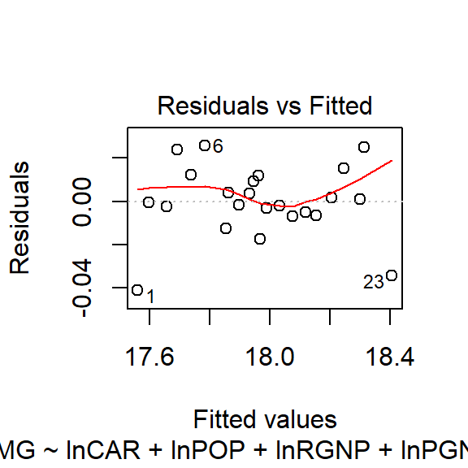

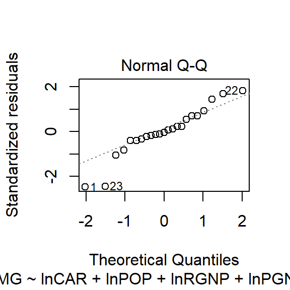

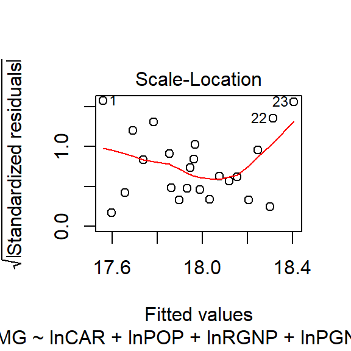

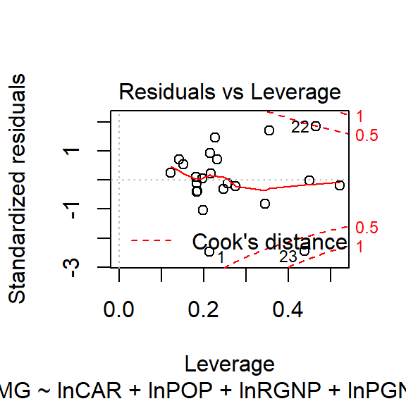

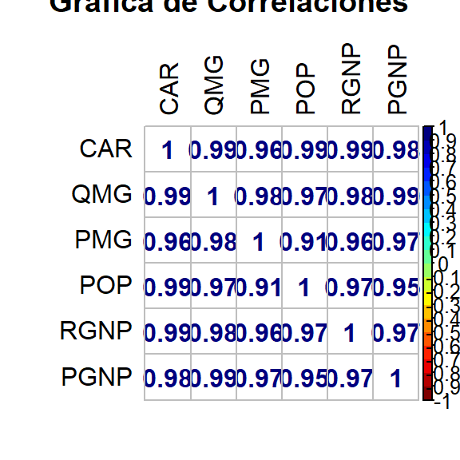

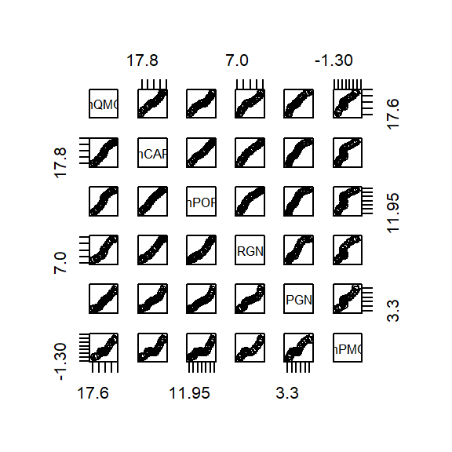

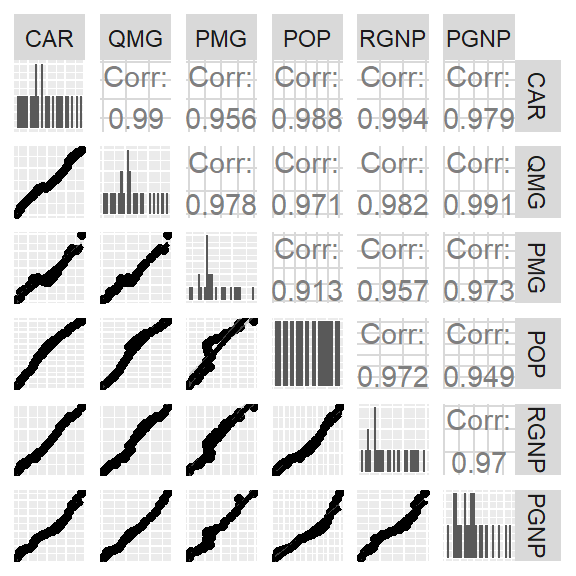

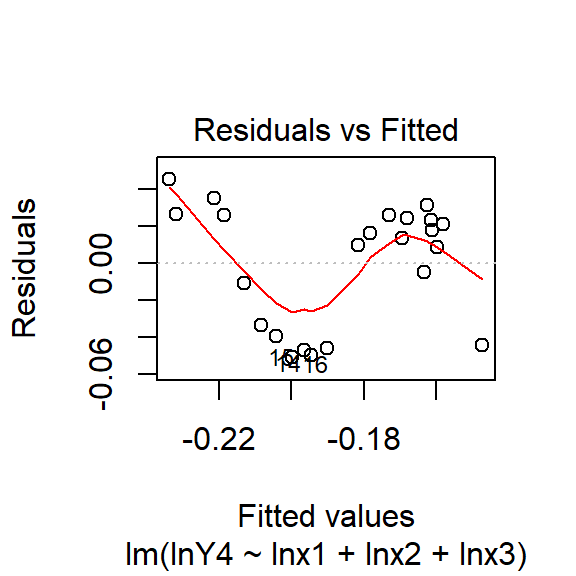

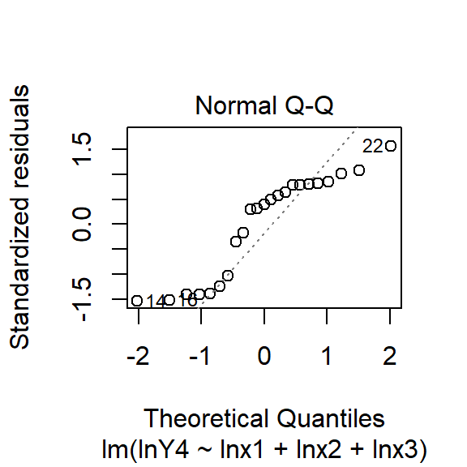

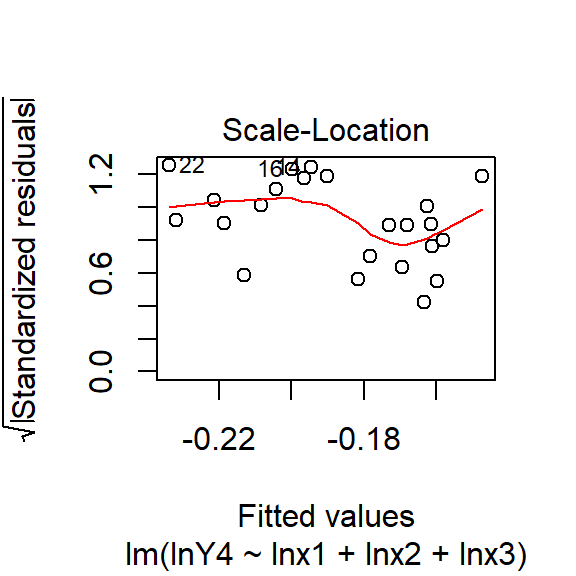

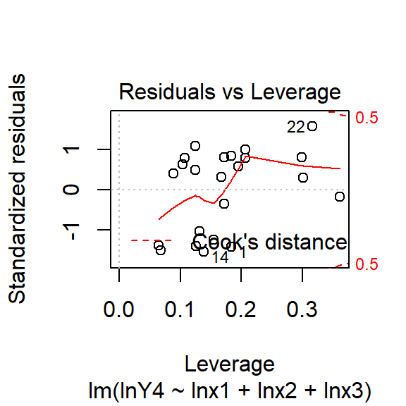

```r
plot(Reg_4.2)
```

(Intercept) -0.30653 2.37844 -0.129 0.899 lnx1 -0.13972 0.23851 -0.586 0.565 lnx2 0.05446 0.28276 0.193 0.849 lnx3 0.18527 0.27882 0.664 0.514 Observamos que en el segundo modelo no nay variables significativas, por lo que este modelo a su vez solo esplica un R2 de 0,389 lo que es un 38% de la varianza del modelo, en la grafica qqplot se observan serias desviaciones respecto de la normal teorica.